# *Game survey findings*

- These are findings we got from a survey we did about gaming in umuzi.

```python
#import your packages
import pandas as ps
import matplotlib as plt

find = ps.read_csv('game.xlsx - Worksheet.csv')
find
```

|  | Timestamp | ID | What device(s) do you use to play games? | What genres do you play? | Do you play online games? | Do you play Single-player, Multiplayer, or both? | Hours per day | Weekly Playing Time |
| --- | --- | --- | --- | --- | --- | --- | --- | --- |
| 0 | 2018/05/15 10:23:39 AM MDT | 1 | Cellphone | Sports | No | Single-player | 1 - 2 hours | One |
| 1 | 2018/05/15 12:00:41 PM MDT | 2 | Laptop | Sports | Maybe | Both | 4+ hours | Two |
| 2 | 2018/05/15 12:38:38 PM MDT | 3 | Cellphone & Desktop | Multiple | No | Both | 1 - 2 hours | Three or more |
| 3 | 2018/05/16 12:38:27 AM MDT | 4 | Cellphone | Maze & Puzzles | Maybe | Single-player | 1 - 2 hours | Three or more |
| 4 | 2018/05/16 3:02:33 AM MDT | 5 | Game Console (PlayStation, XBox, Nintendo, etc) | Multiple | Yes | Multiplayer | 1 - 2 hours | Three or more |
| 5 | 2018/05/16 4:35:16 AM MDT | 6 | Cellphone | Multiple | No | Single-player | 1 - 2 hours | Three or more |
| 6 | 2018/05/16 5:18:02 AM MDT | 7 | Cellphone | Multiple | No | Single-player | 2 - 4 hours | Three or more |
| 7 | 2018/05/16 5:32:53 AM MDT | 8 | Cellphone | Action | No | Both | 1 - 2 hours | One |
| 8 | 2018/05/16 5:36:57 AM MDT | 9 | Game Console (PlayStation, XBox, Nintendo, etc) | Sports | No | Both | 1 - 2 hours | Three or more |
| 9 | 2018/05/16 5:56:47 AM MDT | 10 | Cellphone | Sports | No | Both | 1 - 2 hours | Two |
| 10 | 2018/05/16 6:22:04 AM MDT | 11 | Desktop | Adventure | No | Both | 1 - 2 hours | One |
| 11 | 2018/05/16 6:31:06 AM MDT | 12 | Cellphone | Action | No | Single-player | 1 - 2 hours | Three or more |

```python
#Take desired part
devices = find.groupby('What device(s) do you use to play games?').size().reset_index(name="frq")
devices
```

|  | What device(s) do you use to play games? | frq |
| --- | --- | --- |
| 0 | Cellphone | 7 |
| 1 | Cellphone & Desktop | 1 |
| 2 | Desktop | 1 |
| 3 | Game Console (PlayStation, XBox, Nintendo, etc) | 2 |
| 4 | Laptop | 1 |

## *Plotting the findings*

### *Type of devices used for gaming*

- These are the findings:

```python
device = find.groupby('What device(s) do you use to play games?') .size() .reset_index(name='frq')
device
```

|  | What device(s) do you use to play games? | frq |
| --- | --- | --- |
| 0 | Cellphone | 7 |
| 1 | Cellphone & Desktop | 1 |
| 2 | Desktop | 1 |
| 3 | Game Console (PlayStation, XBox, Nintendo, etc) | 2 |
| 4 | Laptop | 1 |

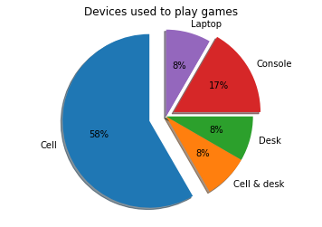

```python
device = find.groupby('What device(s) do you use to play games?') .size() .reset_index(name='frq')
device
plt.pie(device['frq'], labels = ['Cell', 'Cell & desk', 'Desk', 'Console', 'Laptop' ], explode=(0.2, 0.,0.0,0.1,0),
        autopct='%1.0f%%', shadow ='True',startangle=90)
plt.title('Devices used to play games')
plt.axis('equal')
plt.show()
```

#### As we can see more people prefere using their mobile phones then their game console.

- Now we going to plot the amount of people who play online.

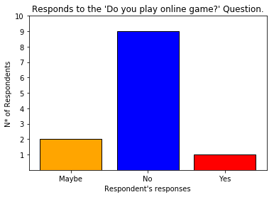

```python
import pandas as ps
import matplotlib.pyplot as plt

find = ps.read_csv('game.xlsx - Worksheet.csv')
online = find.groupby("Do you play online games?").size() .reset_index(name="frq")
x = online['Do you play online games?']
y = online['frq']
colors = ['orange', 'blue', 'red']
plt.bar(x,y, color=colors, edgecolor='black')
plt.yticks([1,2,3,4,5,6,7,8,9,10])
plt.ylabel("N* of Respondents")
plt.xlabel("Respondent's responses")
plt.title("Responds to the 'Do you play online game?' Question.")
plt.show()
```

#### We all know that red is for danger, our above stats show that people who play games online are the minority, which means bad news for us, cause we have to make online games!.

# genres our respondents play

- These are the genres our respondents play.

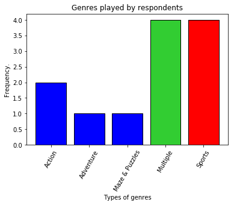

```python
import pandas as ps
import matplotlib.pyplot as plt

find = ps.read_csv('game.xlsx - Worksheet.csv')
genres =find.groupby('What genres do you play?').size().reset_index(name="frq")
colors = ['blue', 'blue','blue','limegreen','red']
x = genres['What genres do you play?']
y = genres['frq']
plt.xticks(rotation=60)
plt.title('Genres played by respondents')
plt.ylabel('Frequency.')
plt.xlabel('Types of genres')

plt.bar(x,y, color = colors, edgecolor="black")
plt.show()
```

#### It"s obvious that more people want to play sports and other generes as well...

# Multiplayer???

- Sometiimes we want to hang out, sometimes we don't but our target is not us. so let's ask our target market how they feel about mutliplayer and singleplayer, do they want either or both?

```python
mode = find.groupby('Do you play Single-player, Multiplayer, or both?').size().reset_index(name="frq")
label = ['']
mode
```

|  | Do you play Single-player, Multiplayer, or both? | frq |
| --- | --- | --- |
| 0 | Both | 6 |
| 1 | Multiplayer | 1 |
| 2 | Single-player | 5 |

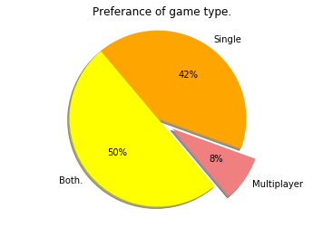

```python
import pandas as ps
import matplotlib.pyplot as plt

find = ps.read_csv('game.xlsx - Worksheet.csv')
mode = find.groupby('Do you play Single-player, Multiplayer, or both?').size().reset_index(name="frq")
label = ['Both.', 'Multiplayer', 'Single']
y= mode['frq']
plt.title('Preferance of game type.')
colors=['yellow','lightcoral','orange']
plt.pie(y, labels=label,startangle=130, explode=(0,0.2,0),shadow='True',colors=colors,autopct='%1.0f%%')
plt.axis("equal")
plt.show()
```

#### Approximately 40% prefer playing alone and Approximately 60% prefer playing multiplayer, I guess we'll have to provide for both of them!!!.

# *How long???*

## In Hours!

- Let's see how long are games played.

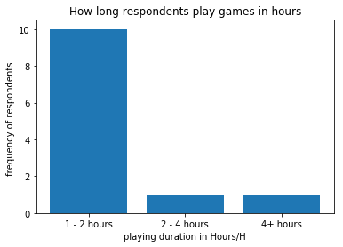

```python
import pandas as ps
import matplotlib.pyplot as plt

find = ps.read_csv('game.xlsx - Worksheet.csv')
hours = find.groupby('Hours per day').size().reset_index(name='freq')
week = find.groupby('Weekly Playing Time').size().reset_index(name='freq')
x1 = hours['Hours per day']
y1 = hours['freq']
plt.title("How long respondents play games in hours")
plt.ylabel("frequency of respondents.")
plt.xlabel("playing duration in Hours/H")
plt.bar(x1,y1)
plt.show()
```

#### More people play games for 1-2 hours.

## *In a Week!*

- Let's see the statistics of how many times people play games in a week.

```python
import pandas as ps
import matplotlib.pyplot as plt

find = ps.read_csv('game.xlsx - Worksheet.csv')
week = find.groupby('Weekly Playing Time').size().reset_index(name='freq')
week
```

|  | Weekly Playing Time | freq |
| --- | --- | --- |
| 0 | One | 3 |
| 1 | Three or more | 7 |
| 2 | Two | 2 |

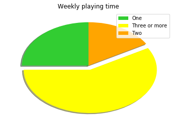

```python
import pandas as ps
import matplotlib.pyplot as plt

find = ps.read_csv('game.xlsx - Worksheet.csv')
week = find.groupby('Weekly Playing Time').size().reset_index(name='freq')
labels = ['One','Three or more', 'Two']
colors = ['limegreen', 'Yellow', 'orange']
y2 = week['freq']

patches, texts = plt.pie(y2, colors=colors, shadow=True, startangle=90,explode=(0,0.1,0))
plt.title('Weekly playing time')
plt.legend(patches, labels, loc="best")
plt.show()
```